# UCL Data Analysis

Elise

2024-06-09

Set the right working directory.

```r
setwd("C:/Users/elise/Documents/Mémoire/Main/Data/Templates/UCL")
```

# Data importation

Import the data sets extracted from the Data Preparation R Markdown.

```r
list.files()
```

```
## [1] "endpoint.txt"     "plant_info.txt"   "S_timeseries.txt" "T_timeseries.txt"
## [5] "timeseries.txt"
```

```r
plant_info <- read.table("plant_info.txt", header = TRUE, sep = "\t")
endpoint <- read.table("endpoint.txt", header = TRUE, sep = "\t")
```

Convert the columns to factor and date formats.

```r
# plant_info
plant_info <- lapply(plant_info, factor)

# endpoint
matching_cols <- intersect(names(endpoint), names(plant_info))
endpoint[, matching_cols] <- lapply(endpoint[, matching_cols], factor)
endpoint$Date <- date(endpoint$Date)
endpoint$Timestamp <- NA

# timeseries
# No data

# S_timeseries
# No data

# T_timeseries
# No data
```

Collect the variables of every data template and print the names of the variables. This serves as a double check.

```r
platform <- "UCL"

# endpoint
df <- endpoint[,colSums(is.na(endpoint))<nrow(endpoint)]
genotype_index <- which(colnames(df) == "Genotype")
variables <- colnames(df[, c(3:(genotype_index - 1))]) # We remove the 3 first columns that are "Unit.ID" and "Date" etc

print(paste(platform, ": The variables for endpoint are", paste(variables, collapse = ", "), sep = " "))
```

```
## [1] "UCL : The variables for endpoint are DW_shoot_g, FW_shoot_g, DW_root_g, FW_root_g"
```

Remove unknown genotypes

```r
endpoint <- endpoint %>%
  filter(Genotype != "Local")
```

Add a column Plant_type with three levels, H L and T. This variable is useful to test for heterosis effects.

```r
endpoint$Plant_type <- substr(endpoint$Genotype, nchar(as.character(endpoint$Genotype)), nchar(as.character(endpoint$Genotype)))
```

# 1. Endpoint dataframe

## A. Exploration of data

### Exploration tables using the rstatix, janitor and skimr packages

```r
endpoint %>%
  count(Genotype)
```

```
##    Genotype  n
## 1   EPPN1_H 29
## 2   EPPN1_L 23
## 3  EPPN10_H 25
## 4  EPPN10_L 10
## 5  EPPN11_H 27
## 6  EPPN11_L 21
## 7  EPPN12_H 25
## 8  EPPN12_L 14
## 9  EPPN13_H 15
## 10 EPPN13_L  6
## 11 EPPN14_H 15
## 12 EPPN14_L  6
## 13 EPPN15_H 25
## 14 EPPN15_L 18
```

[output cut: 17 more lines]

```r
endpoint %>%
  tabyl(Genotype, Column) %>%
  adorn_totals("row") %>%
  adorn_percentages("row") %>%
  adorn_pct_formatting() %>%
  adorn_ns() %>%
  adorn_title("combined")
```

```
##  Genotype/Column          1          2          3          4          5
##          EPPN1_H 10.3%  (3) 10.3%  (3) 10.3%  (3)  6.9%  (2) 10.3%  (3)
##          EPPN1_L  8.7%  (2)  8.7%  (2)  8.7%  (2)  8.7%  (2) 13.0%  (3)
##         EPPN10_H  8.0%  (2)  8.0%  (2)  8.0%  (2)  8.0%  (2) 12.0%  (3)
##         EPPN10_L 10.0%  (1) 20.0%  (2) 20.0%  (2)  0.0%  (0)  0.0%  (0)
##         EPPN11_H 11.1%  (3) 11.1%  (3)  7.4%  (2)  7.4%  (2) 11.1%  (3)
##         EPPN11_L 14.3%  (3)  4.8%  (1)  9.5%  (2)  0.0%  (0) 14.3%  (3)
##         EPPN12_H 12.0%  (3) 12.0%  (3)  8.0%  (2)  8.0%  (2)  8.0%  (2)
##         EPPN12_L  7.1%  (1)  7.1%  (1) 14.3%  (2)  7.1%  (1) 21.4%  (3)
##         EPPN13_H 13.3%  (2) 13.3%  (2) 13.3%  (2)  6.7%  (1) 20.0%  (3)
##         EPPN13_L 16.7%  (1) 16.7%  (1)  0.0%  (0) 16.7%  (1) 16.7%  (1)
##         EPPN14_H  6.7%  (1) 13.3%  (2) 20.0%  (3) 13.3%  (2)  6.7%  (1)
##         EPPN14_L 33.3%  (2) 16.7%  (1) 16.7%  (1) 16.7%  (1) 16.7%  (1)
##         EPPN15_H  8.0%  (2) 12.0%  (3) 12.0%  (3)  8.0%  (2) 12.0%  (3)
##         EPPN15_L 11.1%  (2)  5.6%  (1)  5.6%  (1) 11.1%  (2) 11.1%  (2)
##          EPPN2_H 12.5%  (3)  8.3%  (2)  8.3%  (2)  8.3%  (2)  8.3%  (2)
##          EPPN2_L  5.9%  (1)  0.0%  (0)  5.9%  (1) 17.6%  (3) 17.6%  (3)
##         EPPN20_T  7.4%  (2) 11.1%  (3) 11.1%  (3) 11.1%  (3) 11.1%  (3)
##          EPPN3_H  5.6%  (1) 11.1%  (2) 11.1%  (2) 11.1%  (2) 11.1%  (2)
##          EPPN3_L 10.5%  (2)  5.3%  (1)  5.3%  (1)  5.3%  (1) 10.5%  (2)
##          EPPN4_H  5.0%  (1) 15.0%  (3) 10.0%  (2) 10.0%  (2) 15.0%  (3)
##          EPPN4_L  5.0%  (1)  5.0%  (1) 10.0%  (2) 10.0%  (2) 10.0%  (2)
##          EPPN5_H  6.2%  (1)  6.2%  (1) 12.5%  (2) 12.5%  (2) 18.8%  (3)
##          EPPN5_L 12.5%  (1)  0.0%  (0)  0.0%  (0) 12.5%  (1) 12.5%  (1)
##          EPPN6_H 12.5%  (3)  8.3%  (2)  8.3%  (2) 12.5%  (3) 12.5%  (3)
##          EPPN6_L 11.8%  (2)  5.9%  (1)  5.9%  (1) 17.6%  (3) 11.8%  (2)
##          EPPN7_H 28.6%  (2)  0.0%  (0) 14.3%  (1)  0.0%  (0) 14.3%  (1)
##          EPPN7_L 12.5%  (2)  6.2%  (1) 12.5%  (2) 12.5%  (2)  0.0%  (0)
##          EPPN8_H  9.5%  (2)  9.5%  (2)  9.5%  (2)  4.8%  (1)  9.5%  (2)
##          EPPN8_L 11.1%  (2) 16.7%  (3) 16.7%  (3) 11.1%  (2) 11.1%  (2)
##          EPPN9_H  8.0%  (2)  8.0%  (2) 12.0%  (3) 12.0%  (3) 12.0%  (3)
##          EPPN9_L  4.5%  (1)  9.1%  (2) 13.6%  (3) 13.6%  (3) 13.6%  (3)
##            Local     -  (0)     -  (0)     -  (0)     -  (0)     -  (0)
##            Total  9.9% (57)  9.2% (53) 10.2% (59)  9.5% (55) 11.8% (68)
##           6          7          8          9         10
##  10.3%  (3) 10.3%  (3) 10.3%  (3) 10.3%  (3) 10.3%  (3)
##   8.7%  (2)  8.7%  (2)  8.7%  (2) 13.0%  (3) 13.0%  (3)
##  12.0%  (3) 12.0%  (3) 12.0%  (3)  8.0%  (2) 12.0%  (3)
##  10.0%  (1) 20.0%  (2)  0.0%  (0) 10.0%  (1) 10.0%  (1)
##  11.1%  (3)  7.4%  (2) 11.1%  (3) 11.1%  (3) 11.1%  (3)
```

[output cut: 13 more lines]

```
##  15.8%  (3)  5.3%  (1) 15.8%  (3) 10.5%  (2) 15.8%  (3)
##   5.0%  (1) 10.0%  (2) 15.0%  (3)  5.0%  (1) 10.0%  (2)
##  15.0%  (3) 10.0%  (2) 10.0%  (2) 15.0%  (3) 10.0%  (2)
##  12.5%  (2) 12.5%  (2) 12.5%  (2)  0.0%  (0)  6.2%  (1)
##  12.5%  (1) 25.0%  (2)  0.0%  (0) 12.5%  (1) 12.5%  (1)
##   8.3%  (2)  4.2%  (1) 12.5%  (3)  8.3%  (2) 12.5%  (3)
##   5.9%  (1)  5.9%  (1) 11.8%  (2) 11.8%  (2) 11.8%  (2)
##   0.0%  (0) 14.3%  (1) 14.3%  (1)  0.0%  (0) 14.3%  (1)
##   6.2%  (1) 12.5%  (2) 12.5%  (2) 12.5%  (2) 12.5%  (2)
##  14.3%  (3)  9.5%  (2) 14.3%  (3)  9.5%  (2)  9.5%  (2)
##  11.1%  (2) 11.1%  (2)  0.0%  (0)  5.6%  (1)  5.6%  (1)
##  12.0%  (3)  8.0%  (2) 12.0%  (3)  8.0%  (2)  8.0%  (2)
##  13.6%  (3)  9.1%  (2)  4.5%  (1) 13.6%  (3)  4.5%  (1)
##      -  (0)     -  (0)     -  (0)     -  (0)     -  (0)
##  10.0% (58)  9.0% (52)  9.9% (57) 10.0% (58) 10.6% (61)
```

```r
endpoint %>%
  tabyl(Genotype, Row) %>%
  adorn_totals("row") %>%
  adorn_percentages("row") %>%
  adorn_pct_formatting() %>%
  adorn_ns() %>%
  adorn_title("combined")
```

```
##  Genotype/Row        1         2        3         4        5        6        7
##       EPPN1_H 3.4% (1)  0.0% (0) 0.0% (0)  3.4% (1) 0.0% (0) 3.4% (1) 0.0% (0)
##       EPPN1_L 0.0% (0)  0.0% (0) 0.0% (0)  0.0% (0) 0.0% (0) 0.0% (0) 0.0% (0)
##      EPPN10_H 0.0% (0)  0.0% (0) 4.0% (1)  4.0% (1) 4.0% (1) 0.0% (0) 0.0% (0)
##      EPPN10_L 0.0% (0)  0.0% (0) 0.0% (0)  0.0% (0) 0.0% (0) 0.0% (0) 0.0% (0)
##      EPPN11_H 0.0% (0)  3.7% (1) 0.0% (0)  0.0% (0) 0.0% (0) 3.7% (1) 3.7% (1)
##      EPPN11_L 0.0% (0)  0.0% (0) 0.0% (0)  0.0% (0) 4.8% (1) 0.0% (0) 0.0% (0)
##      EPPN12_H 0.0% (0)  0.0% (0) 4.0% (1)  4.0% (1) 0.0% (0) 0.0% (0) 0.0% (0)
##      EPPN12_L 0.0% (0)  0.0% (0) 0.0% (0)  0.0% (0) 7.1% (1) 0.0% (0) 0.0% (0)
##      EPPN13_H 0.0% (0)  0.0% (0) 0.0% (0)  0.0% (0) 6.7% (1) 0.0% (0) 6.7% (1)
##      EPPN13_L 0.0% (0)  0.0% (0) 0.0% (0)  0.0% (0) 0.0% (0) 0.0% (0) 0.0% (0)
##      EPPN14_H 6.7% (1)  0.0% (0) 0.0% (0)  0.0% (0) 0.0% (0) 6.7% (1) 0.0% (0)
##      EPPN14_L 0.0% (0) 16.7% (1) 0.0% (0)  0.0% (0) 0.0% (0) 0.0% (0) 0.0% (0)
##      EPPN15_H 4.0% (1)  0.0% (0) 0.0% (0)  0.0% (0) 4.0% (1) 0.0% (0) 0.0% (0)
##      EPPN15_L 0.0% (0)  0.0% (0) 0.0% (0)  0.0% (0) 0.0% (0) 0.0% (0) 0.0% (0)
##       EPPN2_H 4.2% (1)  4.2% (1) 4.2% (1)  0.0% (0) 0.0% (0) 0.0% (0) 0.0% (0)
##       EPPN2_L 0.0% (0)  0.0% (0) 5.9% (1)  0.0% (0) 5.9% (1) 0.0% (0) 0.0% (0)
##      EPPN20_T 0.0% (0)  0.0% (0) 0.0% (0)  0.0% (0) 0.0% (0) 0.0% (0) 3.7% (1)
##       EPPN3_H 0.0% (0)  0.0% (0) 0.0% (0)  0.0% (0) 0.0% (0) 0.0% (0) 0.0% (0)
##       EPPN3_L 0.0% (0) 10.5% (2) 0.0% (0)  0.0% (0) 0.0% (0) 0.0% (0) 0.0% (0)
##       EPPN4_H 0.0% (0)  5.0% (1) 0.0% (0)  0.0% (0) 0.0% (0) 0.0% (0) 0.0% (0)
##       EPPN4_L 5.0% (1)  0.0% (0) 0.0% (0)  0.0% (0) 0.0% (0) 0.0% (0) 0.0% (0)
##       EPPN5_H 0.0% (0)  0.0% (0) 0.0% (0)  0.0% (0) 0.0% (0) 0.0% (0) 0.0% (0)
##       EPPN5_L 0.0% (0)  0.0% (0) 0.0% (0)  0.0% (0) 0.0% (0) 0.0% (0) 0.0% (0)
##       EPPN6_H 4.2% (1)  4.2% (1) 0.0% (0)  0.0% (0) 0.0% (0) 0.0% (0) 4.2% (1)
##       EPPN6_L 0.0% (0)  0.0% (0) 0.0% (0)  5.9% (1) 0.0% (0) 0.0% (0) 0.0% (0)
##       EPPN7_H 0.0% (0)  0.0% (0) 0.0% (0) 14.3% (1) 0.0% (0) 0.0% (0) 0.0% (0)
##       EPPN7_L 0.0% (0)  6.2% (1) 0.0% (0)  0.0% (0) 0.0% (0) 6.2% (1) 0.0% (0)
##       EPPN8_H 0.0% (0)  0.0% (0) 4.8% (1)  4.8% (1) 0.0% (0) 0.0% (0) 0.0% (0)
##       EPPN8_L 0.0% (0)  0.0% (0) 5.6% (1)  5.6% (1) 5.6% (1) 0.0% (0) 5.6% (1)
##       EPPN9_H 0.0% (0)  0.0% (0) 4.0% (1)  0.0% (0) 0.0% (0) 0.0% (0) 0.0% (0)
##       EPPN9_L 0.0% (0)  4.5% (1) 0.0% (0)  0.0% (0) 0.0% (0) 0.0% (0) 0.0% (0)
##         Local    - (0)     - (0)    - (0)     - (0)    - (0)    - (0)    - (0)
##         Total 1.0% (6)  1.6% (9) 1.2% (7)  1.2% (7) 1.2% (7) 0.7% (4) 0.9% (5)
##         8         9         10       11       12       13       14        15
##  0.0% (0)  0.0% (0)  0.0%  (0) 3.4% (1) 0.0% (0) 0.0% (0) 3.4% (1)  0.0% (0)
##  0.0% (0)  0.0% (0)  4.3%  (1) 0.0% (0) 0.0% (0) 8.7% (2) 0.0% (0)  4.3% (1)
##  0.0% (0)  0.0% (0)  0.0%  (0) 0.0% (0) 0.0% (0) 0.0% (0) 4.0% (1)  0.0% (0)
##  0.0% (0)  0.0% (0)  0.0%  (0) 0.0% (0) 0.0% (0) 0.0% (0) 0.0% (0) 10.0% (1)
##  0.0% (0)  0.0% (0)  0.0%  (0) 0.0% (0) 0.0% (0) 3.7% (1) 3.7% (1)  0.0% (0)
```

[output cut: 387 more lines]

```
##  0.0% (0) 0.0% (0) 0.0% (0) 0.0% (0)
##  0.0% (0) 0.0% (0) 0.0% (0) 0.0% (0)
##  0.0% (0) 5.0% (1) 0.0% (0) 0.0% (0)
##  6.2% (1) 0.0% (0) 0.0% (0) 6.2% (1)
##  0.0% (0) 0.0% (0) 0.0% (0) 0.0% (0)
##  0.0% (0) 0.0% (0) 0.0% (0) 0.0% (0)
##  0.0% (0) 5.9% (1) 0.0% (0) 0.0% (0)
##  0.0% (0) 0.0% (0) 0.0% (0) 0.0% (0)
##  0.0% (0) 6.2% (1) 0.0% (0) 0.0% (0)
##  0.0% (0) 0.0% (0) 0.0% (0) 4.8% (1)
##  0.0% (0) 0.0% (0) 0.0% (0) 0.0% (0)
##  0.0% (0) 0.0% (0) 0.0% (0) 0.0% (0)
##  0.0% (0) 0.0% (0) 0.0% (0) 4.5% (1)
##     - (0)    - (0)    - (0)    - (0)
##  0.9% (5) 0.7% (4) 0.5% (3) 1.0% (6)
```

```r
get_summary_stats(data = endpoint,
                  variables,
                  type = "common")
```

```
## # A tibble: 4 × 10
##   variable       n   min   max median   iqr  mean    sd    se    ci
##   <fct>      <dbl> <dbl> <dbl>  <dbl> <dbl> <dbl> <dbl> <dbl> <dbl>
## 1 DW_shoot_g   572     0 0.538  0.238 0.122 0.24  0.095 0.004 0.008
## 2 FW_shoot_g   574     0 8.63   3.48  2.07  3.52  1.60  0.067 0.131
## 3 DW_root_g    577     0 0.275  0.102 0.056 0.104 0.048 0.002 0.004
## 4 FW_root_g    576     0 7.29   2.52  1.78  2.57  1.33  0.055 0.109
```

```r
skim(endpoint[variables])
```

Data summary

| Name | endpoint[variables] |
| --- | --- |
| Number of rows | 578 |
| Number of columns | 4 |
| _______________________ |  |
| Column type frequency: |  |
| numeric | 4 |
| ________________________ |  |
| Group variables | None |

**Variable type: numeric**

| skim_variable | n_missing | complete_rate | mean | sd | p0 | p25 | p50 | p75 | p100 | hist |
| --- | --- | --- | --- | --- | --- | --- | --- | --- | --- | --- |
| DW_shoot_g | 6 | 0.99 | 0.24 | 0.09 | 0 | 0.18 | 0.24 | 0.30 | 0.54 | ▂▆▇▃▁ |
| FW_shoot_g | 4 | 0.99 | 3.52 | 1.60 | 0 | 2.51 | 3.48 | 4.58 | 8.63 | ▃▇▇▂▁ |
| DW_root_g | 1 | 1.00 | 0.10 | 0.05 | 0 | 0.07 | 0.10 | 0.13 | 0.28 | ▂▇▆▂▁ |
| FW_root_g | 2 | 1.00 | 2.57 | 1.33 | 0 | 1.65 | 2.51 | 3.43 | 7.29 | ▃▇▆▂▁ |

### Data visualization

Using several functions that are located in the functions.R script

#### Boxplots

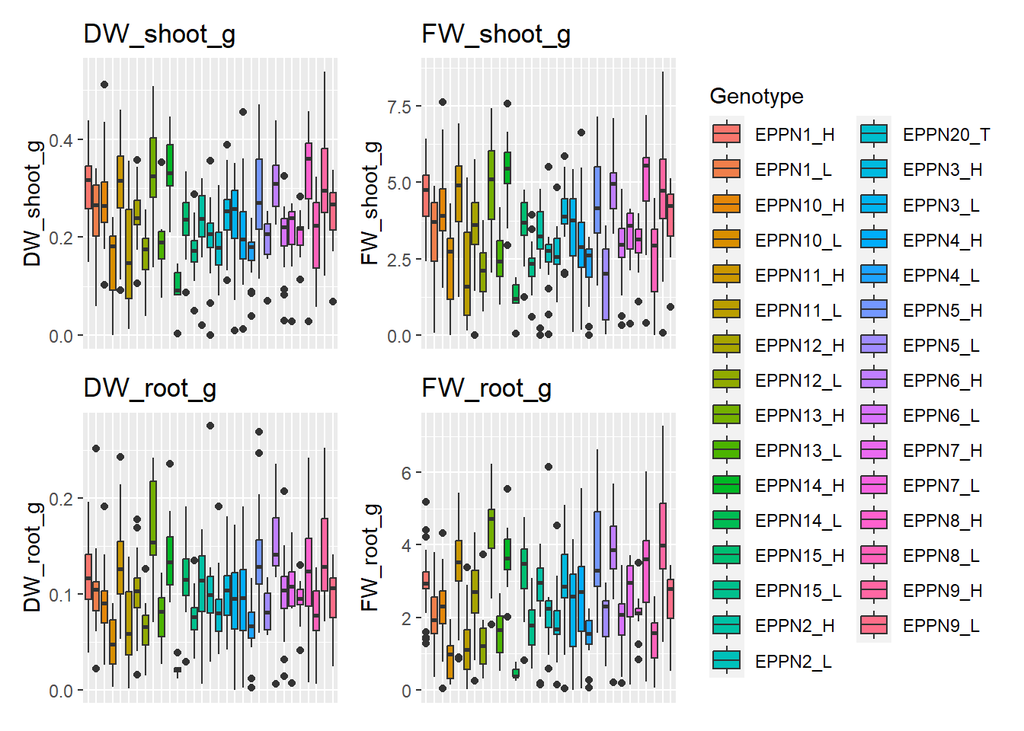

```r
create_boxplots(endpoint, variables, "Genotype")
```

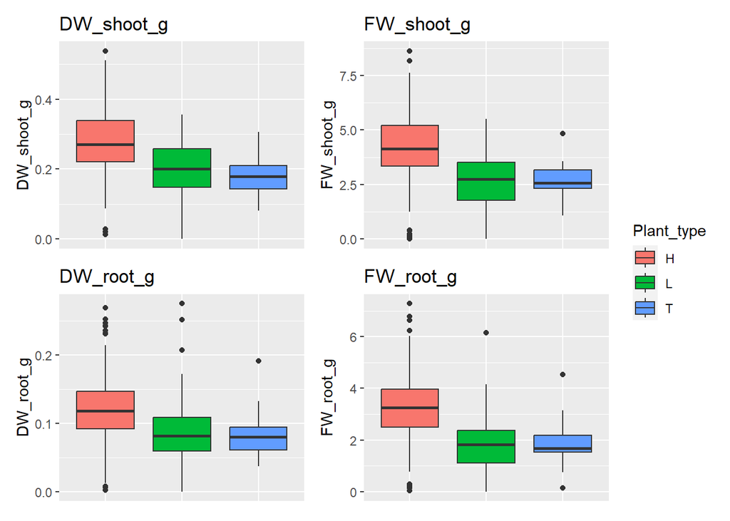

```r
create_boxplots(endpoint, variables, "Plant_type")
```

#### Correlation plots

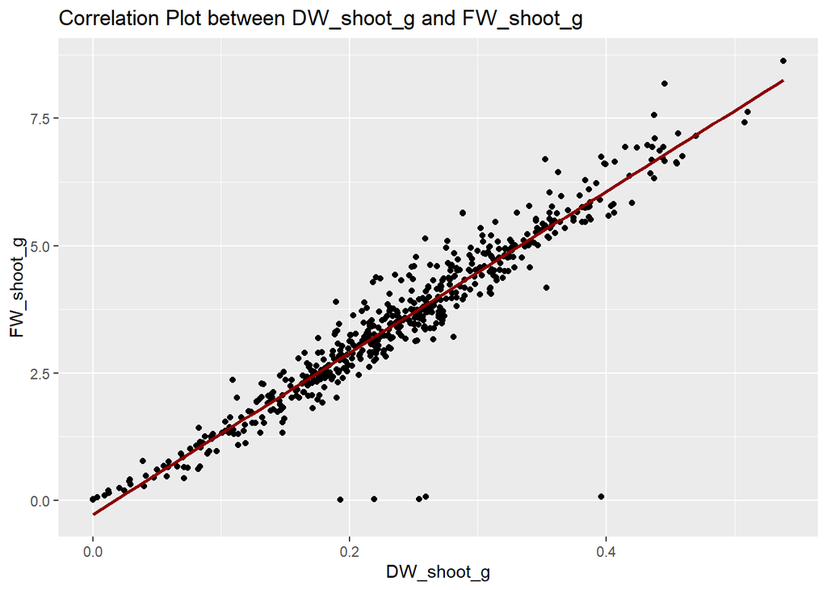

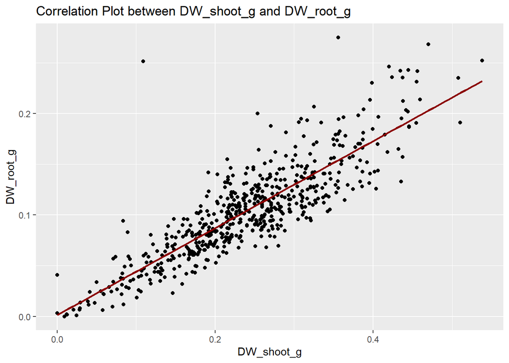

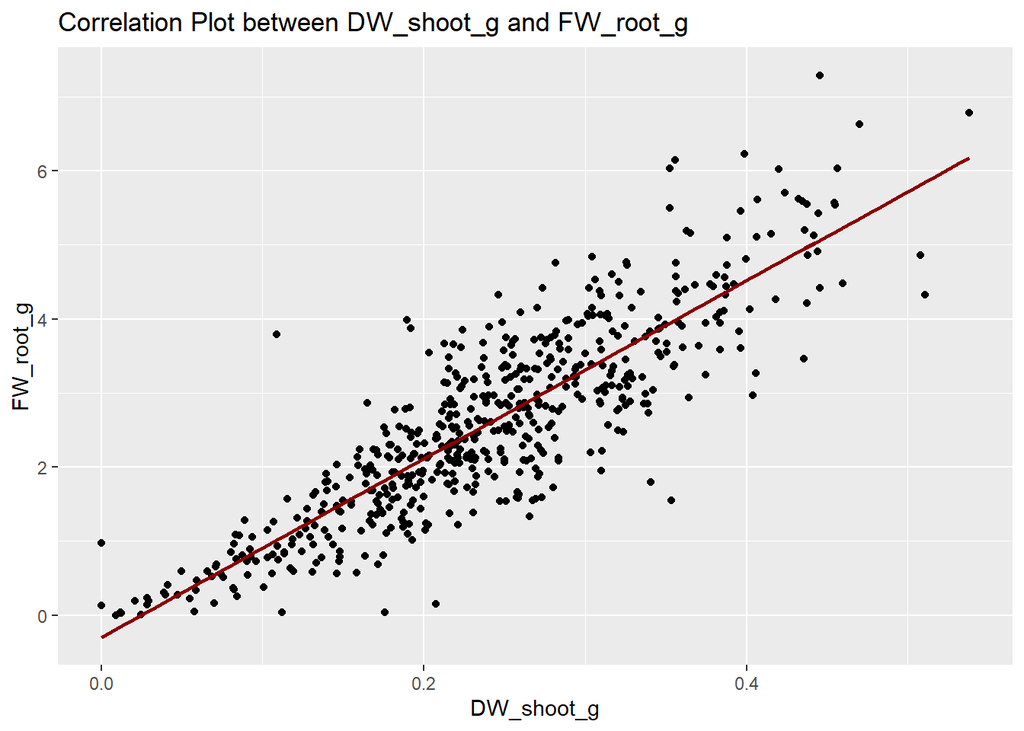

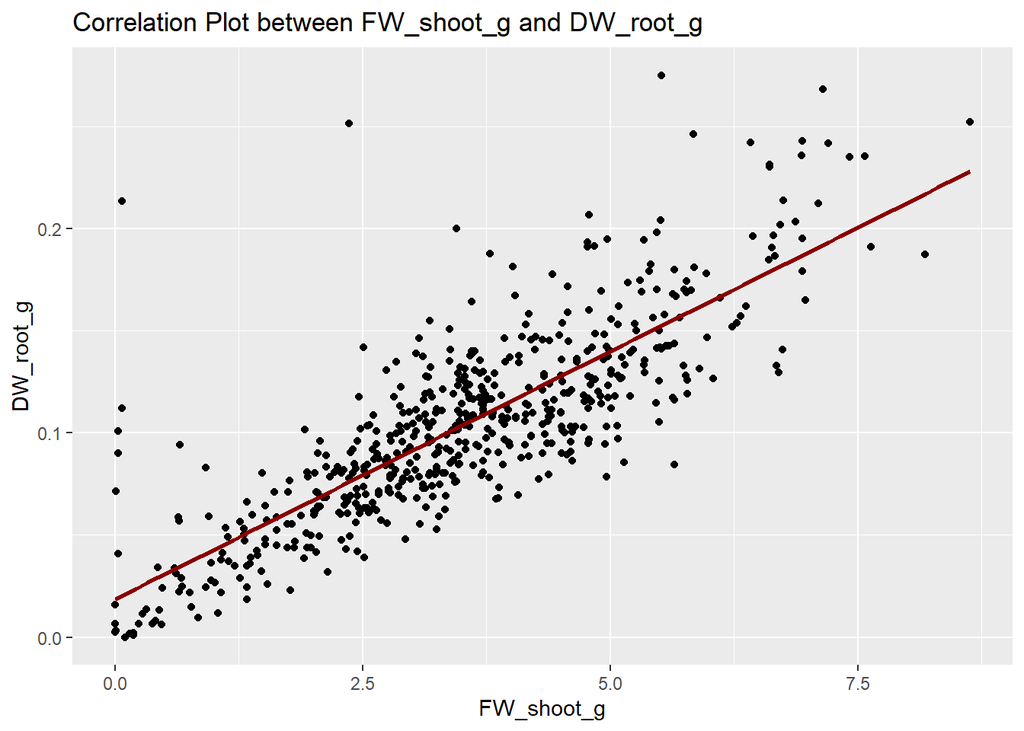

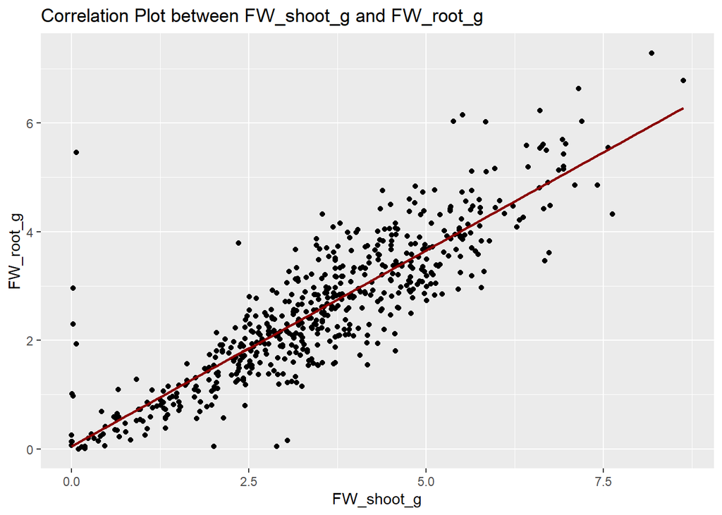

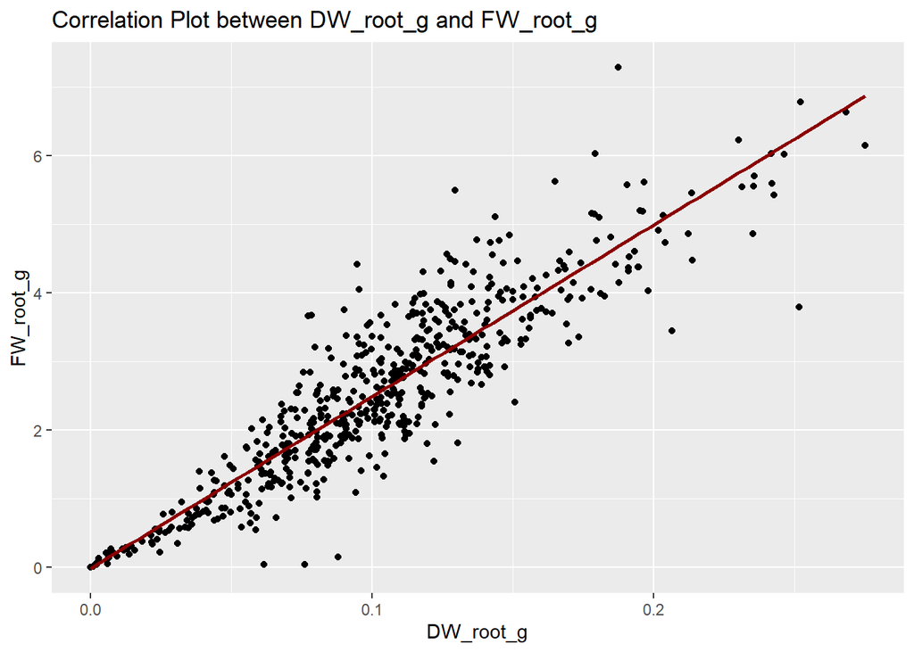

```r
for (i in 1:(length(variables) - 1)) {
  for (j in (i + 1):length(variables)) {
    calculate_correlation_plot(endpoint, variables[i], variables[j])
  }
}
```

## B. Normality hypothesis and outlier detection

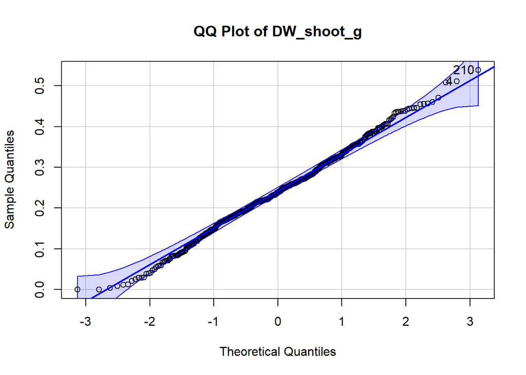

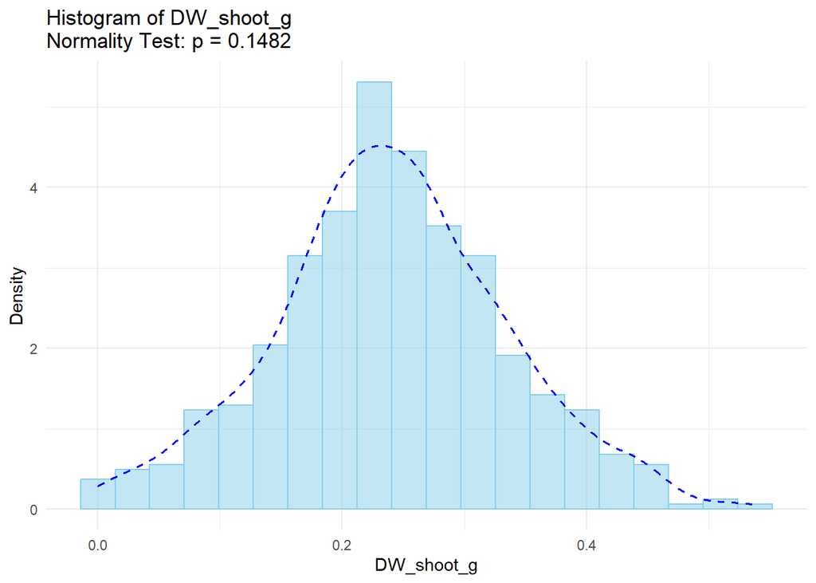

```
## [1] 210   4
```

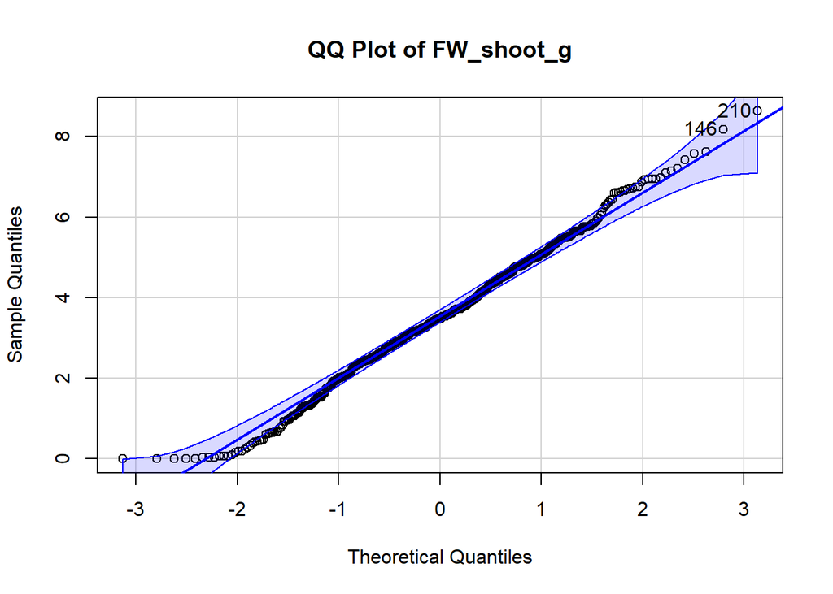

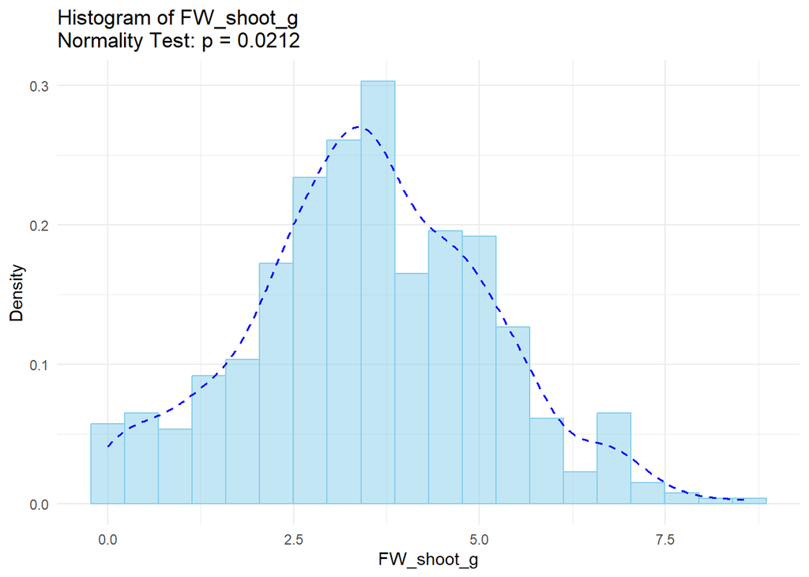

```
## [1] 210 146
```

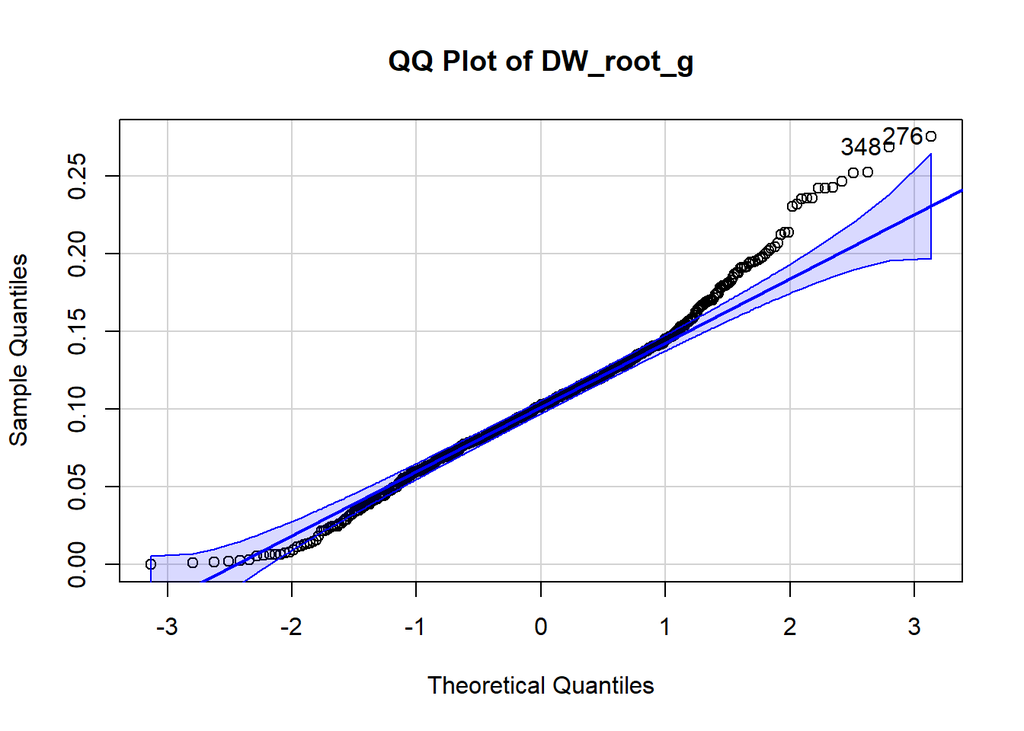

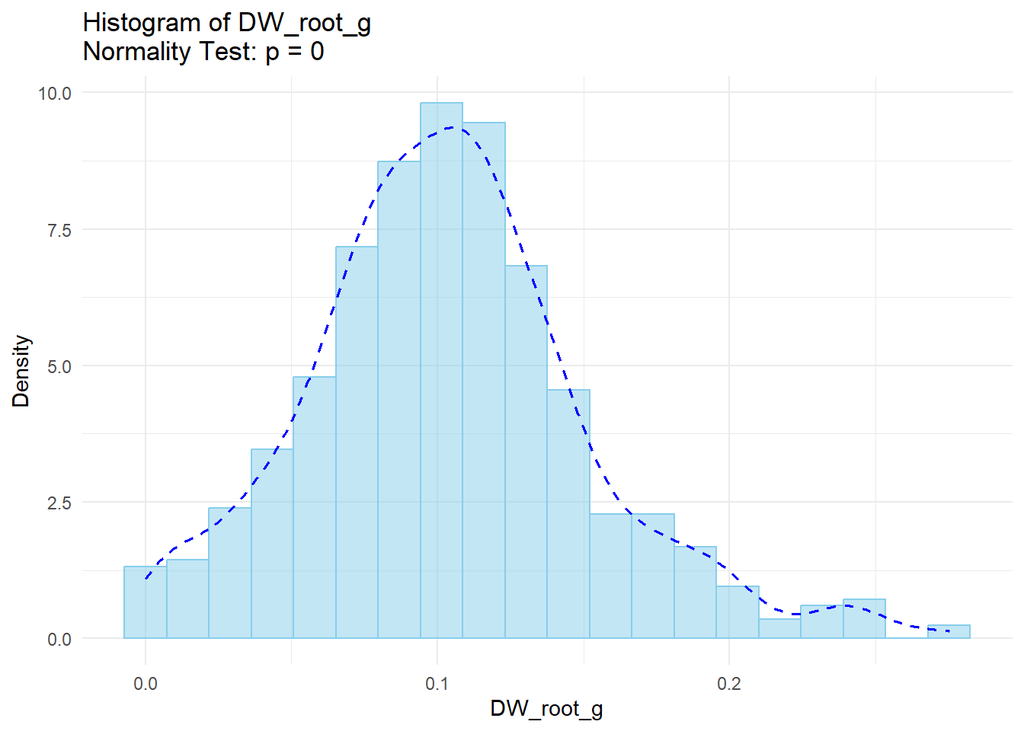

```
## [1] 276 348
```

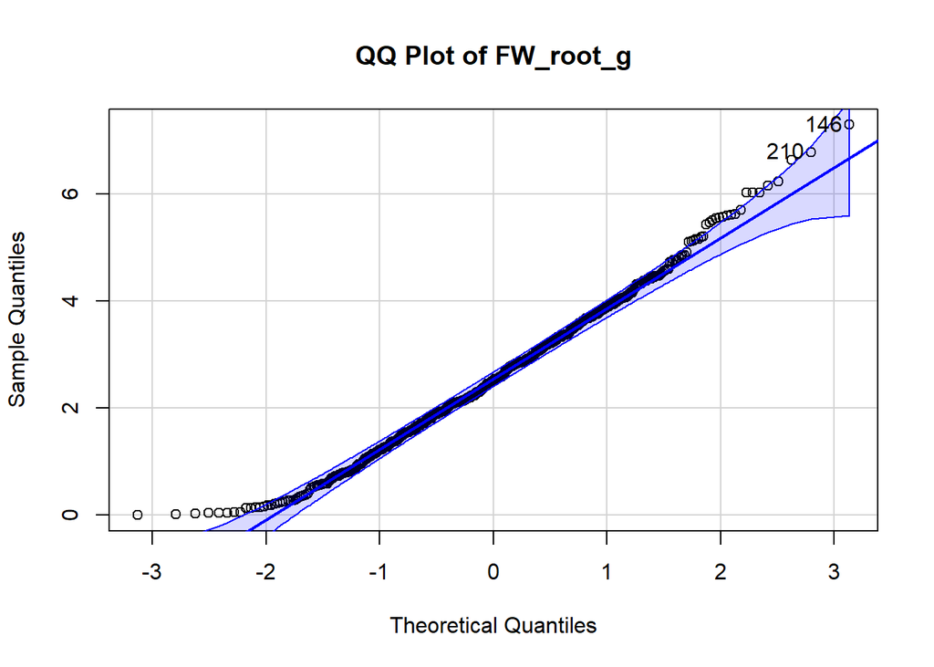

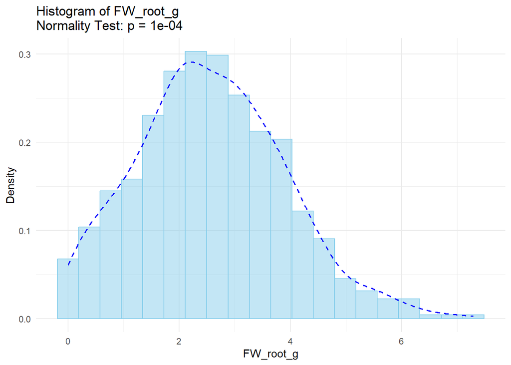

```
## [1] 146 210
```

```r
normality_results <- normality_test_histogram(endpoint)
```

Remove the outliers, replacing them with NULL values and normality visual verification.

The function detect_replace_ouliers_by_genotype checks for outlying values, using the Tukey method.

Then run the function on all variables of the dataset.

```r
endpoint_clean <- endpoint
# Run the function on the dataset for all the variables
endpoint_clean <- detect_replace_outliers_by_genotype(endpoint_clean)
```

### Boxplots after outlier detection

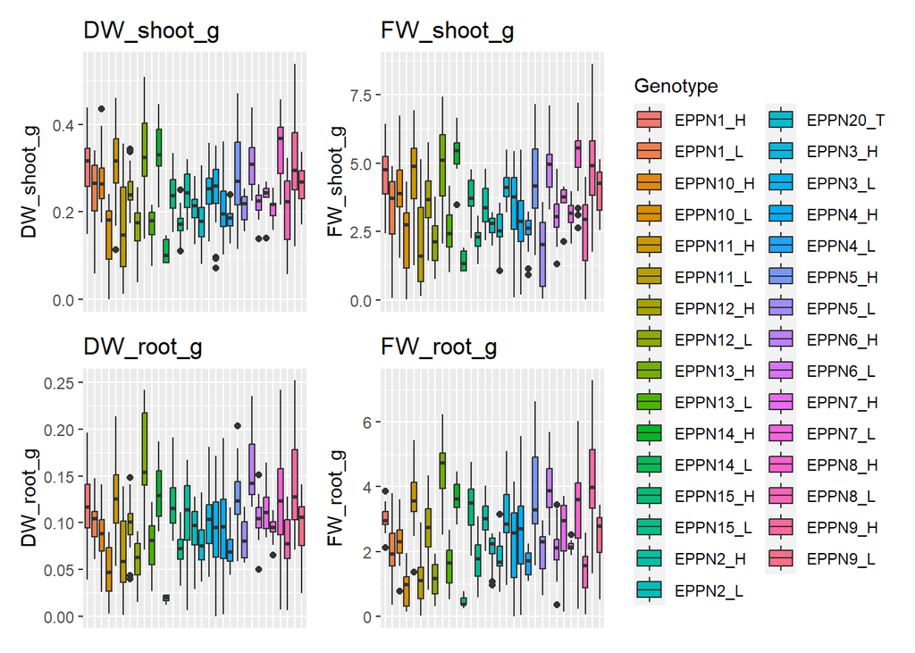

```r
create_boxplots(endpoint_clean, variables, "Genotype")
```

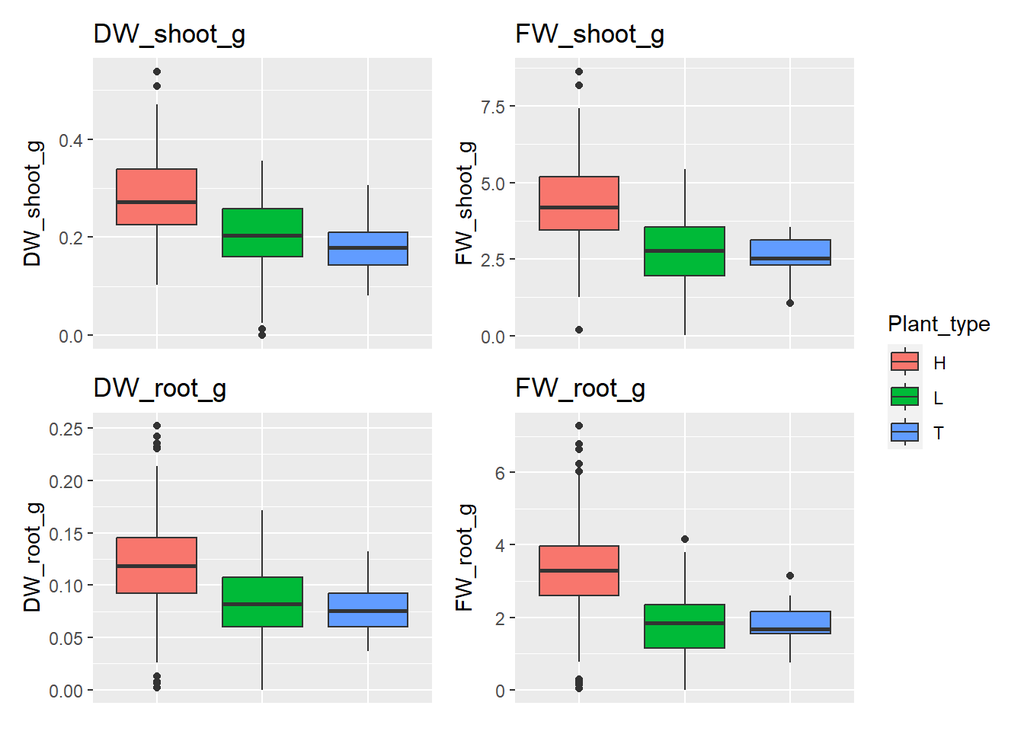

```r
create_boxplots(endpoint_clean, variables, "Plant_type")
```

### Violin and sina plots after outlier detection

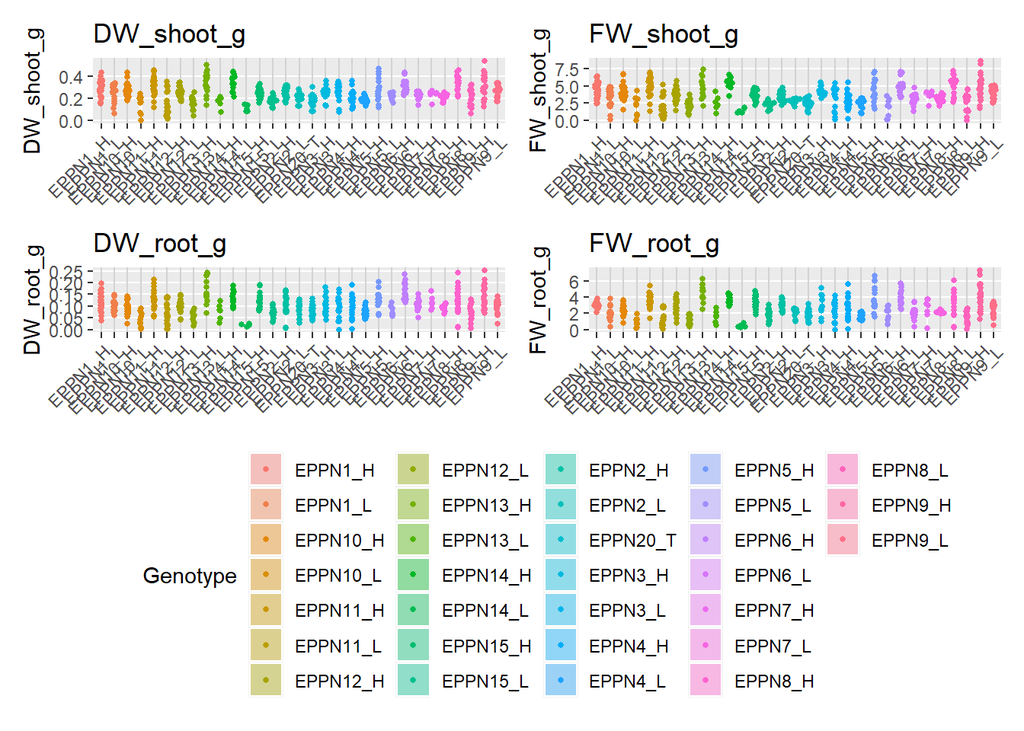

```r
create_violin_plots(endpoint_clean, variables, "Genotype")
```

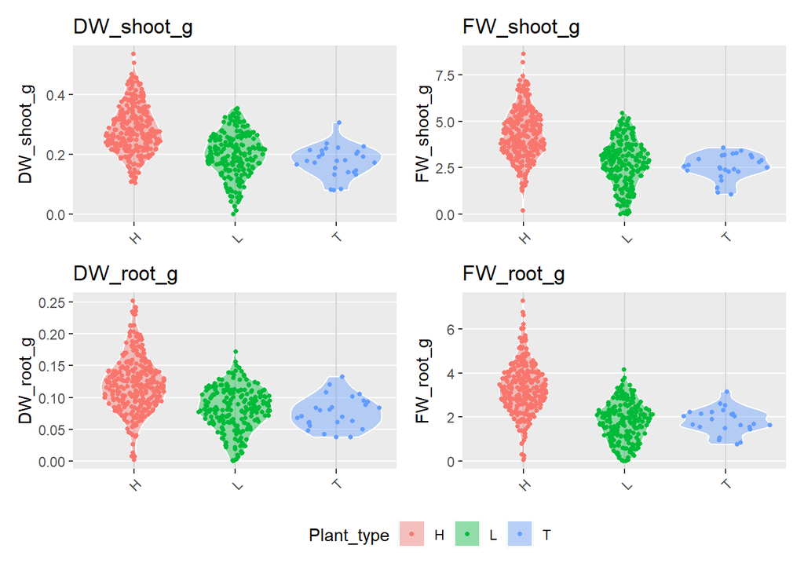

```r
create_violin_plots(endpoint_clean, variables, "Plant_type")
```

### Exploration statistics for the variables after outlier detection

```r
skim(endpoint_clean[variables])
```

Data summary

| Name | endpoint_clean[variables] |
| --- | --- |
| Number of rows | 578 |
| Number of columns | 4 |
| _______________________ |  |
| Column type frequency: |  |
| numeric | 4 |
| ________________________ |  |
| Group variables | None |

**Variable type: numeric**

| skim_variable | n_missing | complete_rate | mean | sd | p0 | p25 | p50 | p75 | p100 | hist |
| --- | --- | --- | --- | --- | --- | --- | --- | --- | --- | --- |
| DW_shoot_g | 38 | 0.93 | 0.25 | 0.09 | 0.00 | 0.19 | 0.24 | 0.30 | 0.54 | ▁▅▇▂▁ |
| FW_shoot_g | 34 | 0.94 | 3.59 | 1.51 | 0.01 | 2.61 | 3.53 | 4.60 | 8.63 | ▂▇▇▂▁ |
| DW_root_g | 26 | 0.96 | 0.10 | 0.04 | 0.00 | 0.07 | 0.10 | 0.13 | 0.25 | ▂▇▇▂▁ |
| FW_root_g | 34 | 0.94 | 2.61 | 1.28 | 0.00 | 1.73 | 2.55 | 3.40 | 7.29 | ▃▇▆▂▁ |

```r
for (var in variables) {
  cat("\nSummary for:", var, "\n")
  endpoint_clean %>%
    group_by(Genotype) %>%
    summarize(mean    = mean(get(var), na.rm = TRUE),
              std.dev = sd(get(var), na.rm = TRUE),
              n_missing  = sum(is.na(get(var)))) %>%
    arrange(desc(mean)) %>%
    print(n = Inf)
}
```

```
##
## Summary for: DW_shoot_g
## # A tibble: 31 × 4
##    Genotype  mean std.dev n_missing
##    <fct>    <dbl>   <dbl>     <int>
##  1 EPPN8_H  0.345  0.0744         3
##  2 EPPN14_H 0.342  0.0710         0
##  3 EPPN13_H 0.333  0.102          0
##  4 EPPN11_H 0.313  0.0807         1
##  5 EPPN6_H  0.312  0.0617         1
##  6 EPPN9_H  0.311  0.100          0
##  7 EPPN1_H  0.297  0.0715         0
##  8 EPPN5_H  0.286  0.105          0
##  9 EPPN10_H 0.271  0.0633         2
## 10 EPPN9_L  0.265  0.0517         1
```

[output cut: 129 more lines]

# 2. Exploration of the timeseries data

In this part, we look at the timeseries, S_timeseries and T_timeseries datasets, also using several functions, located in the functions.R script.

## Number of data observations per day for the traits of the timeseries datasets

```r
print(paste0("No data for", platform))
```

```
## [1] "No data forUCL"
```

## A. Exploration of the timeseries dataframe

Scatter plots by Genotype

```r
print(paste0("No data for", platform))
```

```
## [1] "No data forUCL"
```

Scatterplots for all genotypes by Plant type (Hybride, Line, EPPN20_T) with smooth line.

```r
print(paste0("No data for", platform))
```

```
## [1] "No data forUCL"
```

Scatter plots for all genotypes by water treatment

```r
print(paste0("No data for", platform))
```

```
## [1] "No data forUCL"
```

## B. Exploration of the S_timeseries dataframe

Scatter plots by Genotype

```r
print(paste0("No data for", platform))
```

```
## [1] "No data forUCL"
```

Scatterplots for all genotypes by Plant type (Hybride, Line, EPPN20_T) with smooth line.

```r
print(paste0("No data for", platform))
```

```
## [1] "No data forUCL"
```

Scatter plots for all genotypes by water treatment

```r
print(paste0("No data for", platform))
```

```
## [1] "No data forUCL"
```

## C. Exploration of the T_timeseries dataframe

Scatter plots by Genotype

```r
print(paste0("No data for", platform))
```

```
## [1] "No data forUCL"
```

Scatterplots for all genotypes by Plant type (Hybride, Line, EPPN20_T) with smooth line.

```r
print(paste0("No data for", platform))
```

```
## [1] "No data forUCL"
```

Scatter plots for all genotypes by water treatment

```r
print(paste0("No data for", platform))
```

```
## [1] "No data forUCL"
```